# DAB501 Final Project

## Packages and Data

```r
library(tidyverse)
library(here)
# Assigning the data to a data frame
df <- read.csv(here('data','Group10.csv'))
```

## MODELING: First pair of variables

### Question 1: Identify the explanatory variable.

Temperature(temp): Temperature represents the average daily temperature in degrees Fahrenheit.

### Question 2: Identify the response variable.

Count: Count represents the number of bikes rented on a particular day.

### Question 3: Create a linear regression model and display the full output of the model.

```r
m1 <- lm(count ~ temp, data = df)
summary(m1)
```

```
##
## Call:
## lm(formula = count ~ temp, data = df)
##
## Residuals:
##     Min      1Q  Median      3Q     Max
## -4222.3 -1179.6   -43.3  1090.0  3562.3
##
## Coefficients:
##             Estimate Std. Error t value Pr(>|t|)
## (Intercept) 1031.443    203.315   5.073 5.55e-07 ***
## temp          73.019      3.892  18.764  < 2e-16 ***
## ---
## Signif. codes:  0 '***' 0.001 '**' 0.01 '*' 0.05 '.' 0.1 ' ' 1
##
## Residual standard error: 1493 on 494 degrees of freedom
## Multiple R-squared:  0.4161, Adjusted R-squared:  0.4149
## F-statistic: 352.1 on 1 and 494 DF,  p-value: < 2.2e-16
```

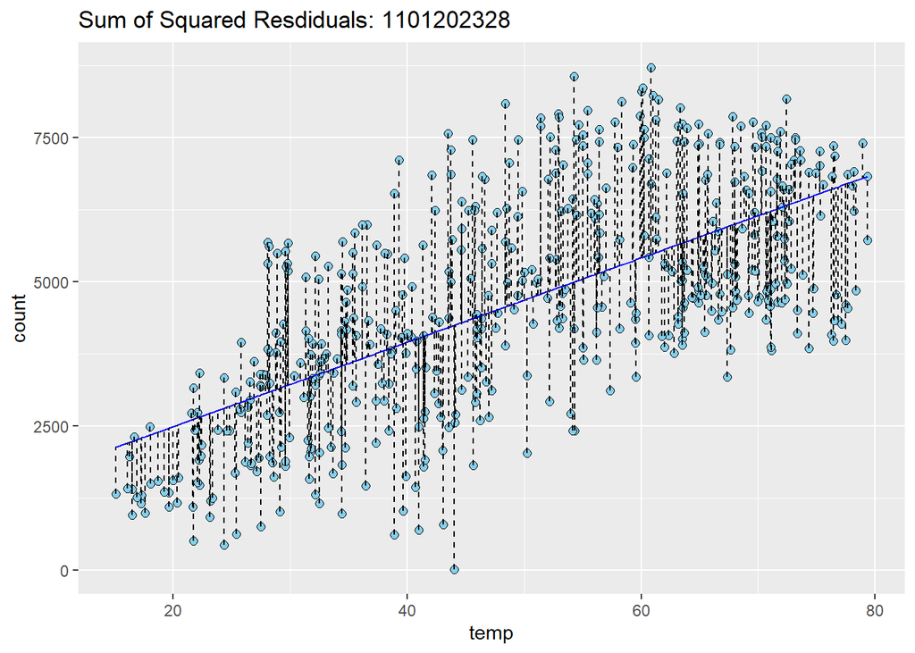

```r
best_line <- function(slope, intercept, residuals = TRUE) {
  data <- df %>% mutate(y_predicted = intercept + slope * temp,
                          square_residuals = (count - y_predicted)^2)

  ssr <- data %>% summarize(ssr = round(sum(square_residuals), 0))

  if (residuals) {
    p <- ggplot(data, aes(x = temp, y = count)) +
          geom_point(shape = 21, fill = 'skyblue', size = 2) +
          geom_line(aes(x = temp, y = y_predicted), colour = 'blue') +
          geom_segment(aes(x = temp, y = count,
                           xend = temp, yend = y_predicted), linetype = 2) +
          ggtitle(paste0("Sum of Squared Resdiduals: ", ssr[[1]]))
  } else {
    p <- ggplot(data, aes(x = temp, y = count)) +
          geom_point(shape = 21, fill = 'skyblue', size = 2) +
          geom_line(aes(x = temp, y = y_predicted), colour = 'blue')
  }
  p
}
best_line(slope = 73.019, intercept = 1031.443)
```

### Question 4: Using the variables noted in #1 and #2 above and the results of #3, write the equation for your model.

```r
m2 <- lm(count ~ temp, data = df)
summary(m2)
```

```
##
## Call:
## lm(formula = count ~ temp, data = df)
##
## Residuals:
##     Min      1Q  Median      3Q     Max
## -4222.3 -1179.6   -43.3  1090.0  3562.3
##
## Coefficients:
##             Estimate Std. Error t value Pr(>|t|)
## (Intercept) 1031.443    203.315   5.073 5.55e-07 ***
## temp          73.019      3.892  18.764  < 2e-16 ***
## ---
## Signif. codes:  0 '***' 0.001 '**' 0.01 '*' 0.05 '.' 0.1 ' ' 1
##
## Residual standard error: 1493 on 494 degrees of freedom
## Multiple R-squared:  0.4161, Adjusted R-squared:  0.4149
## F-statistic: 352.1 on 1 and 494 DF,  p-value: < 2.2e-16
```

Slope: 73.019

Intercept: 1031.443

Formula for Count : Count^ = 1031.443 + 73.019∗temp

### Question 5: Explain what the intercept means in the context of the data.

The intercept is 1031.443. This means that when the temperature is 0 degrees Fahrenheit there will be on average of 1031.443 people using rented bikes on that particular date.

### Question 7: Explain what the slope means in the context of the data.

The slope is 73.019. This means that for every 1 degrees Fahrenheit that the temperature rises by there will be an expected(/predicted) increase of 73.019 people who will rent a bike on average.

## MODELING: Second pair of variables

### Question 1: Identify the explanatory variable.

precipitation: precipitation represents the amount of precipitation, measure in mm

### Question 2: Identify the response variable.

Count: Count represents the number of bikes rented on a particular day.

### Question 3: Create a linear regression model and display the full output of the model.

```r
model1  <- lm(count ~ precipitation ,data=df)
summary(model1)
```

```
##
## Call:
## lm(formula = count ~ precipitation, data = df)
##
## Residuals:
##     Min      1Q  Median      3Q     Max
## -4604.8 -1306.0  -147.7  1286.6  4492.0
##
## Coefficients:
##               Estimate Std. Error t value Pr(>|t|)
## (Intercept)   2658.996    199.206   13.35   <2e-16 ***
## precipitation   43.260      4.008   10.79   <2e-16 ***
## ---
## Signif. codes:  0 '***' 0.001 '**' 0.01 '*' 0.05 '.' 0.1 ' ' 1
##
## Residual standard error: 1758 on 494 degrees of freedom
## Multiple R-squared:  0.1908, Adjusted R-squared:  0.1892
## F-statistic: 116.5 on 1 and 494 DF,  p-value: < 2.2e-16
```

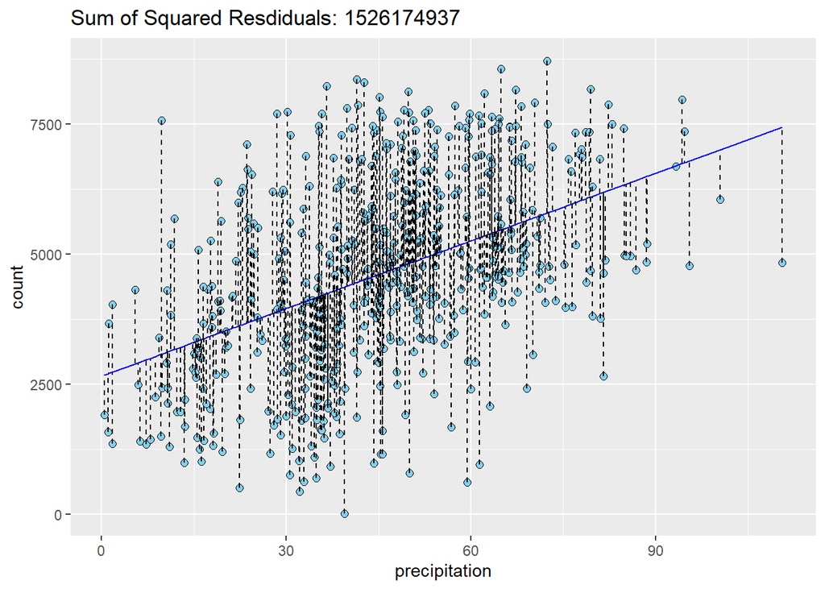

```r
best_line <- function(slope, intercept, residuals = TRUE) {
  mlb <- df %>% mutate(y_predicted = intercept + slope * precipitation,
                          square_residuals = (count - y_predicted)^2)

  ssr <- mlb %>% summarize(ssr = round(sum(square_residuals), 0))

  if (residuals) {
    p <- ggplot(mlb, aes(x = precipitation , y = count)) +
          geom_point(shape = 21, fill = 'skyblue', size = 2) +
          geom_line(aes(x = precipitation, y = y_predicted), colour = 'blue') +
          geom_segment(aes(x = precipitation, y = count,
                           xend = precipitation, yend = y_predicted), linetype = 2) +
          ggtitle(paste0("Sum of Squared Resdiduals: ", ssr[[1]]))
  } else {
    p <- ggplot(df, aes(x = precipitation, y = count)) +
          geom_point(shape = 21, fill = 'skyblue', size = 2) +
          geom_line(aes(x = precipitation, y = y_predicted), colour = 'blue')
  }
  p
}
best_line(slope=43.260, intercept = 2658.996)
```

### Question 4: Using the variables noted in #1 and #2 above and the results of #3, write the equation for your model.

```r
model1  <- lm(count ~ precipitation ,data=df)
summary(model1)
```

```
##
## Call:
## lm(formula = count ~ precipitation, data = df)
##
## Residuals:
##     Min      1Q  Median      3Q     Max
## -4604.8 -1306.0  -147.7  1286.6  4492.0
##
## Coefficients:
##               Estimate Std. Error t value Pr(>|t|)
## (Intercept)   2658.996    199.206   13.35   <2e-16 ***
## precipitation   43.260      4.008   10.79   <2e-16 ***
## ---
## Signif. codes:  0 '***' 0.001 '**' 0.01 '*' 0.05 '.' 0.1 ' ' 1
##
## Residual standard error: 1758 on 494 degrees of freedom
## Multiple R-squared:  0.1908, Adjusted R-squared:  0.1892
## F-statistic: 116.5 on 1 and 494 DF,  p-value: < 2.2e-16
```

Slope: 43.260

Intercept: 2658.996

Formula for Count : Count^ = 2658.996 + 43.260∗precipitation

### Question 5: Explain what the intercept means in the context of the data.

The intercept is 2658.996. This means that when there is 0 mm of precipitation there will be on average of 2658.996 people using rented bikes on that particular date.

### Question 7: Explain what the slope means in the context of the data.

The slope is 43.260. This means that for the rise of every 1 mm of precipitation there will be an expected(/predicted) increase of 43.260 people who will rent a bike on average.

## MODEL ASSESSMENT

### Question 1: Which metric can you use to choose between the two models you just created

R-squared metric cab be used to choose between two models.

### Question 2: Explain what this metric means and why it is good for comparing models.

R-squared metric means this tells how well terms fit a curve or line in linear regression models. It helps in explanatory purposes. This is good for comparing models because it helps in finding out whether there is a relationship between data or not.

### Question 3: According to this metric, which model is the best of the two you created? Why?

Best model will be based on R-squared value. The one with highest R-squared value is the best model. In this case,

Model1:

Count^ = 1031.443 + 73.019∗temp

R^2 = 41.61%

Model2:

Count^ = 2658.996 + 43.260∗precipitation

R^2 = 19.08%

model1 gives the best R^2 value when compared to model 2. So, model1 is the best among two models.

## MODEL DIAGNOSTICS

### Question 1: Create two new data columns based on your best model: predicted values for your response variable and the corresponding residuals.

```r
m1_mod<- df %>% mutate(pred_count=1031.443+73.019*temp,residuals= count-pred_count)

m1_mod %>% select(count,pred_count,temp,residuals)%>% head()
```

|  | count | pred_count | temp | residuals |
| --- | --- | --- | --- | --- |
| 1 | 8227 | 5485.602 | 61.0000 | 2741.3980 |
| 2 | 7538 | 5047.488 | 55.0000 | 2490.5120 |
| 3 | 6779 | 6258.384 | 71.5833 | 520.6160 |
| 4 | 4549 | 5674.232 | 63.5833 | -1125.2320 |
| 5 | 4035 | 3915.694 | 39.5000 | 119.3065 |
| 6 | 3115 | 5217.863 | 57.3333 | -2102.8632 |

### Question 2: Create a plot to check the assumption of linearity. State whether or not this condition is met and explain your reasoning.

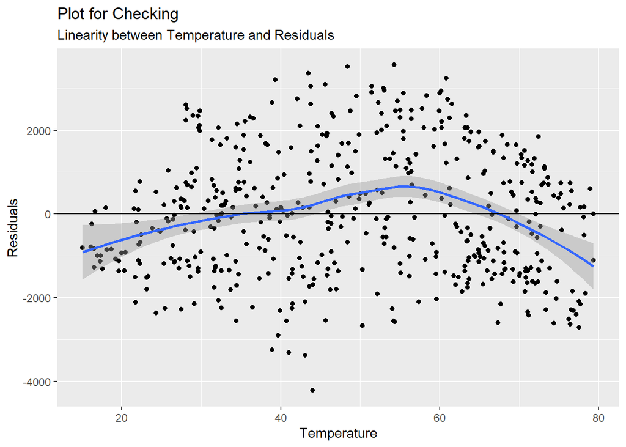

```r
ggplot(m1_mod,aes(x=temp,y=residuals))+
  geom_point()+geom_smooth()+labs(x='Temperature',y='Residuals',title='Plot for Checking',subtitle = 'Linearity between Temperature and Residuals')+
  geom_hline(yintercept = 0)
```

It is evident with the fitting line that the data is non-linear.And, it has an increasing trend until 55 temperature then we can see the fall. Thus, we can say that the condition of linearity is not met.

### Question 3: Create a plot to check the assumption of nearly normal residuals. State whether or not this condition is met and explain your reasoning.

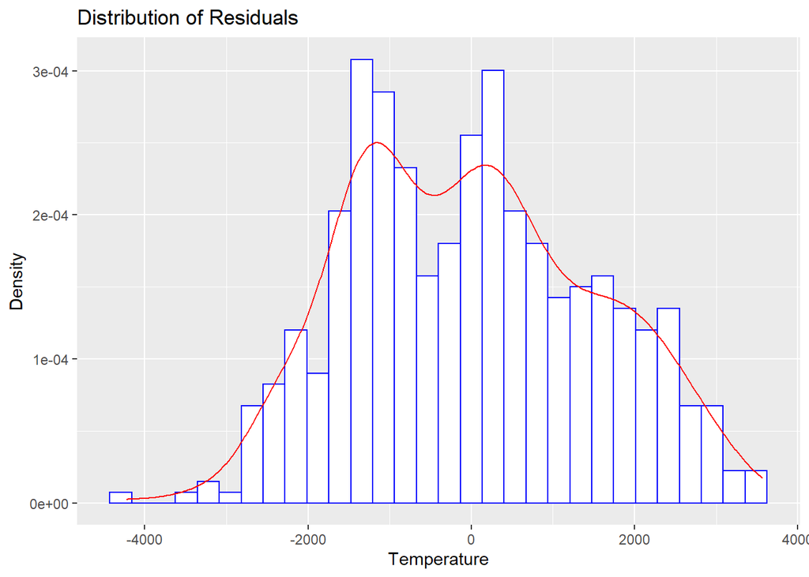

```r
ggplot(m1_mod,aes(x=residuals))+geom_histogram(aes(y=..density..),fill='white',color='blue')+geom_density(color='red')+labs(x='Temperature',y='Density',title='Distribution of Residuals')
```

From the above plot, we cannot really see a perfect bell curve as it is having ups and downs. Thus, we can say that the residuals are not nearly normally distributed.

### Question 4: Create a plot to check the assumption of constant variability. State whether or not this condition is met and explain your reasoning.

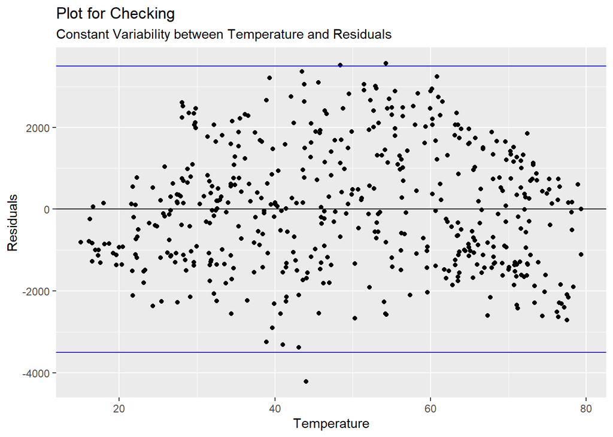

```r
ggplot(m1_mod,aes(x=temp,y=residuals))+
  geom_point()+labs(x='Temperature',y='Residuals',title='Plot for Checking',subtitle = 'Constant Variability between Temperature and Residuals')+
  geom_hline(yintercept = 0)+
  geom_hline(yintercept = 3500,color='blue')+
  geom_hline(yintercept = -3500,color='blue')
```

Though, all the residuals are basically contained within the two horizontal blue lines. These residuals seem to be getting closer and going far away from 0 and it also looks like the points are having a curving pattern changing the variability as the temp increases, thus the constant variability condition is not met

## CONCLUSION

### Question 1: Based on the results of the “Model Diagnostics” section above, what can you conclude about your model?

Since, neither of the conditions i.e., (Linearity, NNR and Constant variability) are met. We cannot reliably use this model to describe the relationship between count and temp and as a way to predict the count of bike given the temperature.